# Cell type specific runs

`r`r dir.create(cell.cwd)

```
'/homes6/asahu/project/deeplearning/icb/data/tcga/scrna.v4.genes/tensorboardLog/no_pipeline_20190724-201216/getz/epoch-52//Cytotoxicity CD8T' already exists
```

## Cell type clustering

`r`r n_neighbors =15; learning_rate =.01; min_dist = 0.1; pca = 10

`r`r

print(umap.all.p[[2]])

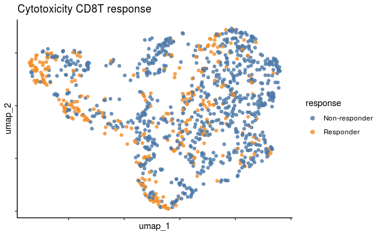

##Check if two clusters are confounded by pre or post or patient.

[output not shown]

`r`r # data.curr[,patient:=] xx = text.clusters.features(data=data.curr, cluster=data.curr[,c(1, 2)], text.cols = .name.small, title=,size=2, filename=sprintf(%s/patient, tsne.dir), normalize=F, do.discrete=T)

`r`r data.curr$shape = data.curr$response data.curr$umap1 = umap.all.p[[1]]$embedding[,1] data.curr$umap2 = umap.all.p[[1]]$embedding[,2] xx = color.clusters.features(data=data.curr, cluster=data.curr[,c(1, 2)], color.cols = .ident.2, title=,size=2, filename=sprintf(%s/patient, tsne.dir), normalize=F, do.discrete=T)

## Cluster based on tsne

`r`r # library(scater) # filename = sprintf(%s/%s_%s_umap_clustering.pdf, tsne.dir, cell.type.curr, ) # # data.tsne= as.data.frame(all.p[[1]]$Y) # data.exp = t(icb.expression.matched) # # # Defining clusters and markers: # library(scran) # data.DI = data_tsne.merge[locx,58:121] # # data.DI = data.tsne # snn.gr <- buildSNNGraph(t(data.DI)) # data.tsne$clust1 = factor(igraph::cluster_walktrap(snn.gr)$membership) # data.tsne.dt = data.table(data.tsne) # data.summ = data.tsne.dt[,.(clust.m=median(V2)),by=clust1] # data.summ = data.summ[order(clust.m)] # data.summ$clust = seq(nrow(data.summ)) # data.tsne$clust = as.factor(data.summ[match(data.tsne$clust1, clust1)]$clust) # data.tsne$cell_name = colnames(data.exp)[locx] # p=ggplot(data.tsne, aes(x=V1, y=V2)) + # geom_point(size=2,aes(color=clust), alpha=0.8) + # guides(colour=guide_legend(override.aes=list(size=4))) + # xlab(1) + ylab(2) + # # ggtitle(label = title) + # theme_light(base_size=20) + # theme(axis.text.x=element_blank(), # axis.text.y=element_blank()) # # if(!is.null(filename)) ggsave(file=filename, p) # # print(p) # ggsave(file=filename, p)

## Cluster based on umap

`r`r library(scater)

`r`r filename = sprintf(%s/%s_%s_tsne_clustering.pdf, tsne.dir, cell.type.curr, )

data.tsne= as.data.frame(umap.all.p[[1]]$embedding) # colnames(data.tsne) =c(\UMAP1\, \UMAP2\) data.curr$UMAP1 = data.tsne$V1 data.curr$UMAP2 = data.tsne$V2 data.curr = data.table(data.curr) # data.curr = data.curr[match(rownames(icb.expression.matched), sample.name)] # # Defining clusters and markers: library(scran) embedding.mat = data.curr[,.SD, .SDcols=names(data.curr) %like% \^embedding\] data.DI = embedding.mat # data.DI = data.curr[[grep(\^embedding\, names(data.curr))]] snn.gr <- buildSNNGraph(t(data.DI), k=20, d =60) cluster1.igraph = factor(igraph::cluster_walktrap(snn.gr, steps = 10)$membership) data.curr[,response.bin:=ifelse(response==,1,0)] data.summ = data.curr[,.(clust.m=mean(response.bin)),by=cluster1.igraph] data.summ = data.summ[order(clust.m)] data.summ$clust = seq(nrow(data.summ)) match.inx = match(cluster1.igraph, data.summ$cluster1.igraph) data.curr$cluster = as.factor(data.summ[match.inx]$clust) p=ggplot(data.curr, aes(x=UMAP1, y=UMAP2)) + geom_point(size=2,aes(color=cluster), alpha=0.8) + guides(colour=guide_legend(override.aes=list(size=4))) + xlab(1) + ylab(2) + # ggtitle(label = title) + theme_light(base_size=20) + scale_color_tableau() + theme_classic() + theme(axis.text.x=element_blank(), axis.text.y=element_blank()) # if(!is.null(filename)) ggsave(file=filename, p)

## Cell cycle analysis

`r`r cell.cycle = fread(/liulab/asahu/data/ssgsea/xiaoman/getz/Gad_cell_cycle_score.csv) data.curr$cell.cycle = as.factor(cell.cycle[match(data.curr$sample.name, V1)]$Phase) data.curr$G2M.Score = cell.cycle[match(data.curr$sample.name, V1)]$G2M.Score data.curr$S.Score = cell.cycle[match(data.curr$sample.name, V1)]$S.Score cell.cycle.monocyte = cell.cycle[match(data.tsne$sample.name, V1)] p=ggplot(data.curr, aes(x=UMAP1, y=UMAP2)) + geom_point(size=1,aes(color=cell.cycle), alpha=0.7) + guides(colour=guide_legend(override.aes=list(size=4))) + xlab(1) + ylab(2) + # ggtitle(label = title) + theme_light(base_size=20) + scale_color_tableau() + theme_classic() + theme(axis.text.x=element_blank(), axis.text.y=element_blank()) # if(!is.null(filename)) ggsave(file=filename, p) print(p) ggsave(sprintf(%s/umap_clustering_cell_cycle.pdf, tsne.dir),p)

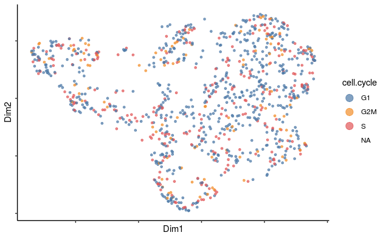

`r`r # cell.cycle.monocyte = cell.cycle[match(data.tsne$sample.name, V1)] # cell.cycle.monocyte$clust = data.tsne$clust # p=ggplot(cell.cycle.monocyte, aes(x=S.Score, y=G2M.Score)) + # geom_point(size=2,aes(color=cluster), alpha=0.8) + # guides(colour=guide_legend(override.aes=list(size=4))) + # # xlab(1) + ylab(2) + # # ggtitle(label = title) + # theme_light(base_size=20) + # theme(axis.text.x=element_blank(), # axis.text.y=element_blank()) # ggsave(sprintf(%s/umap_clustering_lustering_cell_cycle.pdf, tsne.dir),p)

## Diffusion map

`r`r library(destiny) library(Biobase) library(ggthemes) library(scater) set.seed(1234) dm.obj= DiffusionMap(data.curr[,.SD, .SDcols=names(data.curr) %like% ^embedding], density_norm=F, rotate = F) data.curr$diffusionmap1 = eigenvectors(dm.obj)[, 1] data.curr$diffusionmap2 = eigenvectors(dm.obj)[, 2] p.dm1 = ggplot(data.curr, aes(x = diffusionmap1, y = diffusionmap2, colour = response)) + geom_point(alpha=0.7) + scale_color_tableau() + xlab(component 1) + ylab(component 2) + theme_classic()

`r`r p.dm2 = ggplot(data.curr, aes(x = diffusionmap1, y = diffusionmap2, colour = cluster)) + geom_point() + scale_color_tableau() + xlab(component 1) + ylab(component 2) + theme_classic()

ggsave(filename = sprintf(%s/%s_%s_diffusion_cluster.pdf, tsne.dir, cell.type.curr, ),p.dm1)

`r`r dp = DPT(dm.obj) data.curr$dpt = dp$dpt p.dm3 <- ggplot(data.curr, aes(x = diffusionmap1, y = diffusionmap2, colour = dpt)) + geom_point() + xlab(component 1) + ylab(component 2)+ theme_classic()

ggsave(filename = sprintf(%s/%s_%s_diffusion_cluster.pdf, tsne.dir, cell.type.curr, ),p.dm1)

## Slingshot

Adopted from [Slingshot Vignette](https://bioconductor.org/packages/release/bioc/vignettes/slingshot/inst/doc/vignette.html)

`r`r library(slingshot)

```
RGL: unable to open X11 display'rgl_init' failed, running with rgl.useNULL = TRUE
```

`r`r library(gam)

`r`r # ?sli ngshot # slingshot.out = slingshot(embedding.mat, clusterLabels = data.curr$cluster, reducedDim = 'PCA') mat = as.matrix(embedding.mat) rownames(mat) = data.curr$sample.name sce = SingleCellExperiment(assays = list(tpm= t(mat))) dm = cbind(DC1 = dm.obj$DC1, DC2 = dm.obj$DC2) dm2 = eigenvectors(dm.obj)[, 1:2] reducedDims(sce)= SimpleList(DiffMap = dm, DiffMap2 = dm2) colData(sce)$graph = data.curr$cluster slingshot.out = slingshot(sce, clusterLabels = , reducedDim = ‘DiffMap2’)

[output not shown]

`r`r library(RColorBrewer) colors <- colorRampPalette(brewer.pal(11,‘Spectral’))(100) plotcol <- colors[cut(slingshot.out$slingPseudotime_1, breaks=100)]

plot(reducedDims(slingshot.out)$DiffMap, col = as.factor(data.curr$response), pch=16, asp = 1) lines(SlingshotDataSet(slingshot.out), lwd=2, col=‘black’)

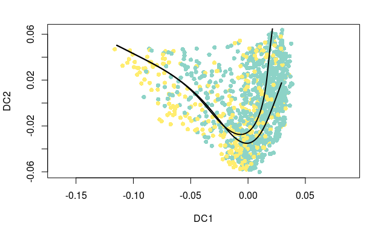

`r`r

require(gam) require(clusterExperiment)

`r`r t <- slingshot.out$slingPseudotime_1

# fit a GAM with a loess term for pseudotime

gam.pval <- apply(t(embedding.mat),1,function(z){ d <- data.frame(z=z, t=t) tmp <- gam(z ~ lo(t), data=d) p <- summary(tmp)[4][[1]][1,5] p })

[output not shown]

`r`r ## Loading required package: clusterExperiment topgenes <- names(sort(gam.pval[gam.pval<1E-10], decreasing = FALSE)) heatdata <- assay(sce)[topgenes,order(t, na.last = NA)] # rownames(heatdata) = heatclus <- slingshot.out$graph[order(t, na.last = NA)] ce <- ClusterExperiment(heatdata, heatclus) plotHeatmap(ce, clusterSamplesData = , visualizeData = ‘transformed’)

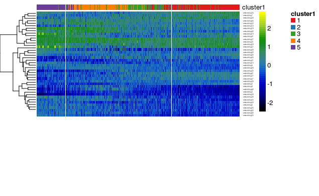

`r`r

library(ComplexHeatmap)

[output not shown]

`r`r Heatmap(heatdata, name = vs Phenotypes, #title of legend column_title = , row_title = , row_names_gp = gpar(fontsize = 7), # Text size for row names column_names_gp = gpar(fontsize = 6) # Text size for row names )

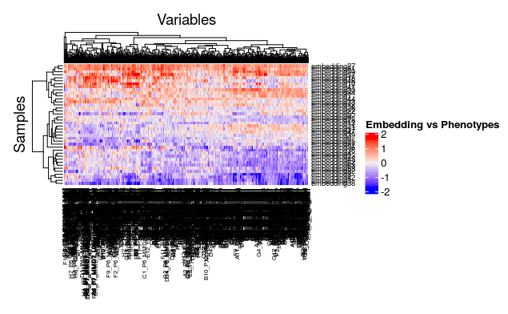

## Plot all the immune genes and factors

`r`r save.dir = sprintf(%s/diffusionmap/, cell.cwd) dir.create(save.dir) save.dir = sprintf(%s/diffusionmap/gene/, cell.cwd) dir.create(save.dir) checkpoint.genes.curr = intersect(checkpoint.genes, colnames(icb.expression.matched)) data.all = as.data.frame(as.matrix(icb.expression.matched[cell.type.inx, checkpoint.genes.curr])) colnames(data.all) = gsub(checkpoint.genes.curr, pattern=-, replacement = .) xx = color.clusters.features( data=data.all, cluster=data.curr[,.(diffusionmap1, diffusionmap2)], color.cols = colnames(data.all), title=,size=2, filename=sprintf(%s/gene, save.dir), normalize=F, do.discrete=F)

# p <- plot_grid(p.dm1, p.dm2, p.dm3, nrow=2)

p.genes <- plot_grid(plotlist = xx.new, nrow=3)

## Plot phenotypes

`r`r

if.exp =icb.phenotype[cell.type.inx, c(if.all.inx),with=F] embedding.exp =icb.phenotype[cell.type.inx, c(embedding.inx),with=F] colnames(if.exp) = gsub(if.all.inx,pattern=.output$, replacement = \ )

if.exp = as.data.frame(if.exp) colnames(if.exp) = gsub(colnames(if.exp), pattern=-, replacement = .)

# data_tsne.merge[,embedding.inx]

save.dir = sprintf(%s/diffusionmap/if2/, cell.cwd) dir.create(save.dir) if.xx= color.clusters.features( data=if.exp, cluster=data.curr[,.(diffusionmap1, diffusionmap2)], color.cols = colnames(if.exp), title=,size=2, filename=sprintf(%s/if, save.dir), normalize=F, do.discrete=F)

`r`r # if.xx1 = if.xx

## For cell type specific genes

`r`r library(dplyr)

# Change the clustering (https://github.com/satijalab/seurat/issues/252)[here]

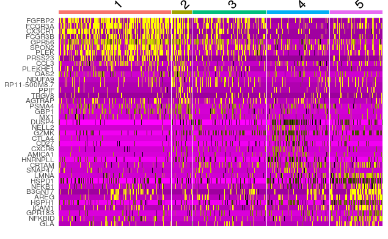

## Evaluate the markers in Genentech data

1. Individual gene expression
2. SSGSEA
3. Estimate the fraction in each tumors

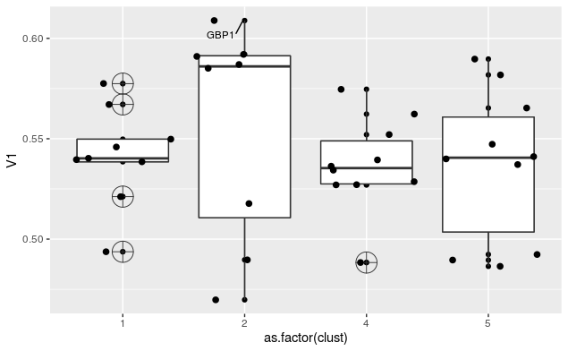

## Estimate the cell fraction in bulk tumor

1. Differential expression fold change. Choose genes to include in differential expression.
2. Calculate the fold change in the genetech data.
3. Calculate roc
4. Create function
5. Find alternative to etstimate cell fraction

`r`r

dataset_phenotype = fread(/liulab/asahu/data/ssgsea/xiaoman/Avin/clinical_ICB_oxphos.txt) genentech.phenotype_sel.mod = dataset_phenotype[match(colnames(genentech.exp), bcr_patient_barcode)] genentech.phenotype_sel.mod[, Response:=as.double(Response)] genentech.phenotype_sel.mod[is.na(Response) & (vital_status == 1) & (survive < 3)]$Response = 0 genentech.phenotype_sel.mod[is.na(Response) & (survive > 7)]$Response = 1 genentech.response = new.genentech.response = genentech.phenotype_sel.mod$Response

```r
readcount2tpm = function (count, gene.length){
    gene.length = gene.length/1000
    count.per.kb = count/gene.length
    tot = sum(count.per.kb, na.rm = T)
    tpm.fac = tot/1e+06
    count.per.kb/tpm.fac
}

genes2consider = intersect(rownames(sco.curr),  genentech.feat$symbol)
sce3 = sco.curr[genes2consider,]

rownames(genentech.exp) = genentech.feat$symbol
genetech.matched = genentech.exp[genes2consider,]
genetech.matched = readcount2tpm(genetech.matched, genentech.feat$length[match(genes2consider, genentech.feat$symbol)])
genentech.logfc = log(genetech.matched +1)
genentech.logfc = genentech.logfc - rowMeans(genentech.logfc)

deepImmune.cluster = data.curr$cluster[match(colnames(sce3), data.curr$sample.name)]
max_clust = max(as.numeric(deepImmune.cluster))
out.list = list()
for (tt in seq(2,max_clust)) {
    set.combo = combn(1:max_clust, tt)
    for(uu in seq(ncol(set.combo))){
        sets = set.combo[,uu]
        for (xx in seq(length(sets)-1)) {
            set1 = sets[seq(xx)]
            set2 = setdiff(sets, set1)
            my.clusters = ifelse(deepImmune.cluster %in% set1, 1, ifelse(data.curr$cluster %in% set2, 0, NA))
            na.inx = which(!is.na(my.clusters))
            # markers <- findMarkers(sce2[,na.inx], my.clusters[na.inx])
            sce4 = sce3[,na.inx]
            Idents(object = sce4) <- sce4@meta.data$deepImmune.clust <- my.clusters[na.inx]
            sce4.markers <- FindAllMarkers(sce4, only.pos = TRUE, min.pct = 0.25, logfc.threshold = 0.25)
            logfc.eff = ifelse(sce4.markers$cluster==1, sce4.markers$avg_logFC, -sce4.markers$avg_logFC)
            score = cor(logfc.eff, genentech.logfc[rownames(sce4.markers),], method="spearman", use="pairwise.complete.obs")
            complete.auc = calc.stat.new(genentech.response, score[1,])
            dt1  = data.table(complete.auc[1],complete.auc[2], genes = "complete1")

            top10 <- sce4.markers %>% group_by(cluster) %>% top_n(n = 5, wt = avg_logFC)
            logfc.eff = ifelse(top10$cluster==1, top10$avg_logFC, -top10$avg_logFC)
            score = cor(logfc.eff, genentech.logfc[top10$gene,], method="spearman", use="pairwise.complete.obs")
            complete.auc = calc.stat.new(genentech.response, score[1,])
            dt2  = data.table(complete.auc[1],complete.auc[2], genes = "complete2")


            out = lapply(top10$gene, function(gene.curr) {
                calc.stat.new(genentech.response,genentech.exp[gene.curr,])
            })
            out.dt = data.table(do.call(rbind, out))
            out.dt$genes = top10$gene
            out.dt = rbind(out.dt, dt1, dt2)
            out.dt$set1=paste(set1,collapse = ",")
            out.dt$set2=paste(set2,collapse = ",")
            out.list = append(out.list, out.dt)
        }
    }


}
# out.list.dt = do.call(rbind, out.list)
xx = list()
for (tt in seq(length(out.list)/5)) {
    xx[[tt]] = data.table(do.call(cbind, out.list[5*(tt-1) + (1:5)]))

}
out.list.dt = do.call(rbind, xx)
out.list.dt = out.list.dt[order(V1,decreasing = T)]
out.list.dt[order(V1,decreasing = T)][genes=="complete2"]
# out.list.dt[set2==max_clust][genes=="complete"]
# list(complete.auc=complete.auc, out.dt=out.dt)
# colnames(mark1)
save.image(sprintf("%s/Alldata.RData", cell.cwd))
```